# ADP6

```r
library(tidyverse)
library(data.table)
library(lubridate)
library(caret)
library(recipes)
library(rsample)
library(forecast)
```

# 1 고객 이탈 분류 문제

## 1.1 Data description

**시험 때 나왔던 데이터**

| 성별 | 나이 | 카드등급 | 소득 | …(15개 더) | y(고객이탈여부) |
| --- | --- | --- | --- | --- | --- |

**시험과 비슷한 데이터**

```r
churn <- fread("data/BankChurners.csv")

churn <- churn %>%
  select(-c(Naive_Bayes_Classifier_Attrition_Flag_Card_Category_Contacts_Count_12_mon_Dependent_count_Education_Level_Months_Inactive_12_mon_1, Naive_Bayes_Classifier_Attrition_Flag_Card_Category_Contacts_Count_12_mon_Dependent_count_Education_Level_Months_Inactive_12_mon_2, CLIENTNUM)) %>%
  janitor::clean_names()

churn %>%
  head() %>%
  gt::gt()
```

| attrition_flag | customer_age | gender | dependent_count | education_level | marital_status | income_category | card_category | months_on_book | total_relationship_count | months_inactive_12_mon | contacts_count_12_mon | credit_limit | total_revolving_bal | avg_open_to_buy | total_amt_chng_q4_q1 | total_trans_amt | total_trans_ct | total_ct_chng_q4_q1 | avg_utilization_ratio |
| --- | --- | --- | --- | --- | --- | --- | --- | --- | --- | --- | --- | --- | --- | --- | --- | --- | --- | --- | --- |
| Existing Customer | 45 | M | 3 | High School | Married | $60K - $80K | Blue | 39 | 5 | 1 | 3 | 12691 | 777 | 11914 | 1.335 | 1144 | 42 | 1.625 | 0.061 |
| Existing Customer | 49 | F | 5 | Graduate | Single | Less than $40K | Blue | 44 | 6 | 1 | 2 | 8256 | 864 | 7392 | 1.541 | 1291 | 33 | 3.714 | 0.105 |
| Existing Customer | 51 | M | 3 | Graduate | Married | $80K - $120K | Blue | 36 | 4 | 1 | 0 | 3418 | 0 | 3418 | 2.594 | 1887 | 20 | 2.333 | 0.000 |
| Existing Customer | 40 | F | 4 | High School | Unknown | Less than $40K | Blue | 34 | 3 | 4 | 1 | 3313 | 2517 | 796 | 1.405 | 1171 | 20 | 2.333 | 0.760 |
| Existing Customer | 40 | M | 3 | Uneducated | Married | $60K - $80K | Blue | 21 | 5 | 1 | 0 | 4716 | 0 | 4716 | 2.175 | 816 | 28 | 2.500 | 0.000 |
| Existing Customer | 44 | M | 2 | Graduate | Married | $40K - $60K | Blue | 36 | 3 | 1 | 2 | 4010 | 1247 | 2763 | 1.376 | 1088 | 24 | 0.846 | 0.311 |

- Attrition_flag : target variable, 이탈 고객인지 유무
- Gender: 성별
- customer age : 고객의 나이
- income category : 고객이 속한 소득 범주
- card category : 고객이 갖고 있는 카드 범주
- month inactive : 신용카드를 사용할 때 비활성 금액
- credit limit : 카드 한도
- total revolving balance : 다음달로 이월되는 미지급 금액
- average utilization ratio : 사용 한도와 비교해서 사용 중인 금액의 비율
- open to buy : 특정 고객에게 할당된 평균 사용 가능 금액

https://www.kaggle.com/sakshigoyal7/credit-card-customers

## 1.2 EDA 및 전처리

```r
library(GGally)
churn %>% glimpse()
```

```
## Rows: 10,127
## Columns: 20
## $ attrition_flag           <chr> "Existing Customer", "Existing Customer", "Ex~
## $ customer_age             <int> 45, 49, 51, 40, 40, 44, 51, 32, 37, 48, 42, 6~
## $ gender                   <chr> "M", "F", "M", "F", "M", "M", "M", "M", "M", ~
## $ dependent_count          <int> 3, 5, 3, 4, 3, 2, 4, 0, 3, 2, 5, 1, 1, 3, 2, ~
## $ education_level          <chr> "High School", "Graduate", "Graduate", "High ~
## $ marital_status           <chr> "Married", "Single", "Married", "Unknown", "M~
## $ income_category          <chr> "$60K - $80K", "Less than $40K", "$80K - $120~
## $ card_category            <chr> "Blue", "Blue", "Blue", "Blue", "Blue", "Blue~
## $ months_on_book           <int> 39, 44, 36, 34, 21, 36, 46, 27, 36, 36, 31, 5~
## $ total_relationship_count <int> 5, 6, 4, 3, 5, 3, 6, 2, 5, 6, 5, 6, 3, 5, 5, ~
## $ months_inactive_12_mon   <int> 1, 1, 1, 4, 1, 1, 1, 2, 2, 3, 3, 2, 6, 1, 2, ~
## $ contacts_count_12_mon    <int> 3, 2, 0, 1, 0, 2, 3, 2, 0, 3, 2, 3, 0, 3, 2, ~
## $ credit_limit             <dbl> 12691.0, 8256.0, 3418.0, 3313.0, 4716.0, 4010~
## $ total_revolving_bal      <int> 777, 864, 0, 2517, 0, 1247, 2264, 1396, 2517,~
## $ avg_open_to_buy          <dbl> 11914.0, 7392.0, 3418.0, 796.0, 4716.0, 2763.~
## $ total_amt_chng_q4_q1     <dbl> 1.335, 1.541, 2.594, 1.405, 2.175, 1.376, 1.9~
## $ total_trans_amt          <int> 1144, 1291, 1887, 1171, 816, 1088, 1330, 1538~
## $ total_trans_ct           <int> 42, 33, 20, 20, 28, 24, 31, 36, 24, 32, 42, 2~
## $ total_ct_chng_q4_q1      <dbl> 1.625, 3.714, 2.333, 2.333, 2.500, 0.846, 0.7~
## $ avg_utilization_ratio    <dbl> 0.061, 0.105, 0.000, 0.760, 0.000, 0.311, 0.0~
```

```r
churn <- churn %>%
  mutate_if(is.character, as.factor)
```

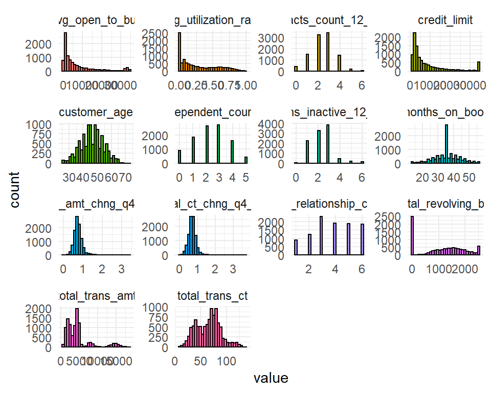

```r
churn %>%
  keep(is.numeric) %>%
  gather() %>%
  ggplot() +
  geom_histogram(mapping = aes(x=value,fill=key), color="black") +
  facet_wrap(~ key, scales = "free") +
  theme_minimal() +
  theme(legend.position = 'none')
```

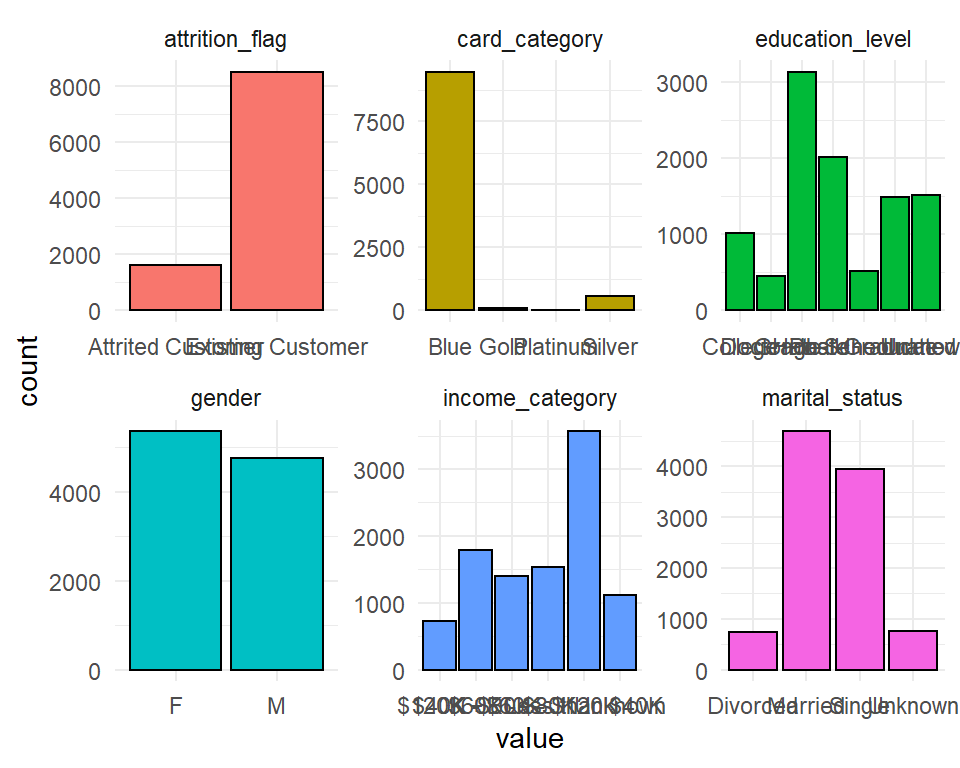

```r
churn %>%
  keep(is.factor) %>%
  gather() %>%
  ggplot() +
  geom_bar(mapping = aes(x=value,fill=key), color="black") +
  facet_wrap(~ key, scales = "free") +
  theme_minimal() +
  theme(legend.position = 'none')
```

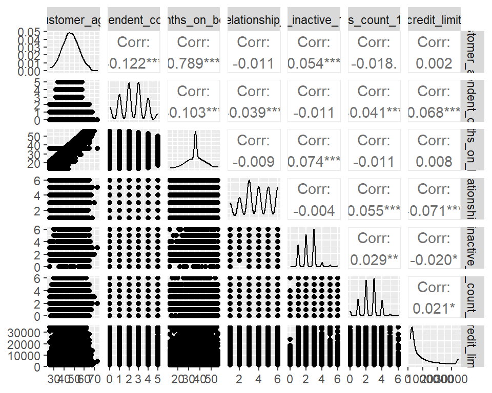

```r
churn %>%
  select_if(is.numeric) %>%
  ggpairs(columns = 1:7)
```

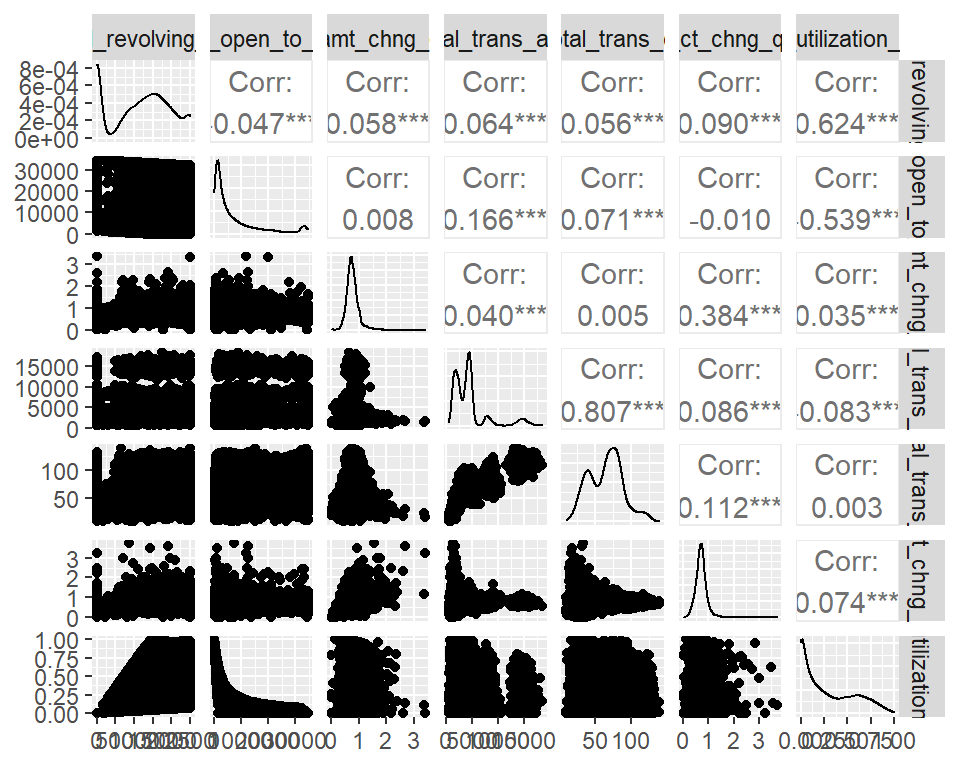

```r
churn %>%
  select_if(is.numeric) %>%
  ggpairs(columns = 8:14)
```

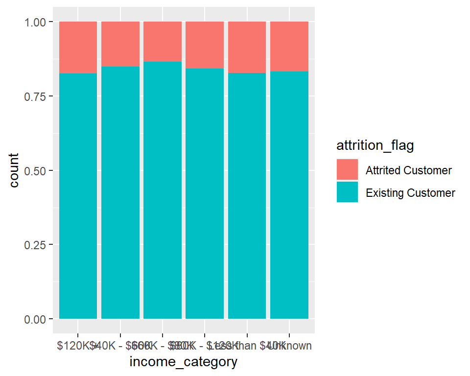

```r
churn %>%
  ggplot(aes(x = income_category, fill = attrition_flag)) +
  geom_bar(position = "fill")
```

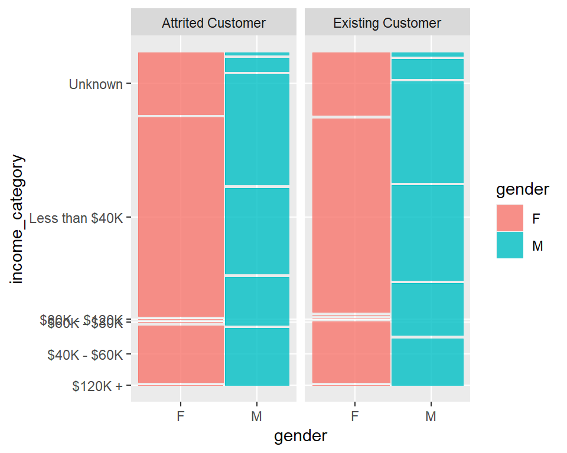

```r
library(ggmosaic)
churn %>%
  ggplot() +
  geom_mosaic(aes(x = product(income_category, gender), fill = gender)) +
  facet_grid(. ~attrition_flag)
```

**범주 불균형 처리**

```r
churn %>% is.na() %>% colSums()
```

```
##           attrition_flag             customer_age                   gender
##                        0                        0                        0
##          dependent_count          education_level           marital_status
##                        0                        0                        0
##          income_category            card_category           months_on_book
##                        0                        0                        0
## total_relationship_count   months_inactive_12_mon    contacts_count_12_mon
##                        0                        0                        0
##             credit_limit      total_revolving_bal          avg_open_to_buy
##                        0                        0                        0
##     total_amt_chng_q4_q1          total_trans_amt           total_trans_ct
##                        0                        0                        0
##      total_ct_chng_q4_q1    avg_utilization_ratio
##                        0                        0
```

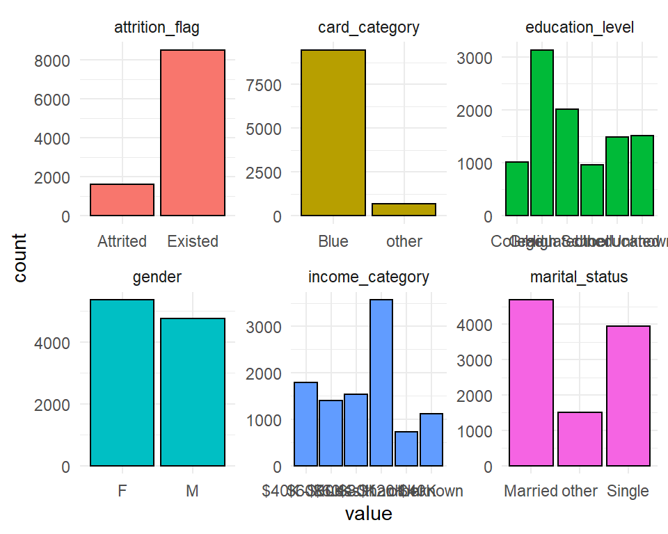

```r
rec <- churn %>%
  recipe(attrition_flag~.) %>%
  step_other(all_nominal(), threshold = 0.1) %>%
  step_mutate(attrition_flag = factor(attrition_flag, labels = c("Attrited", "Existed")))
churn <- rec %>% prep() %>% juice()



churn %>%
  keep(is.factor) %>%
  gather() %>%
  ggplot() +
  geom_bar(mapping = aes(x=value,fill=key), color="black") +
  facet_wrap(~ key, scales = "free") +
  theme_minimal() +
  theme(legend.position = 'none')
```

## 1.3 분류모델 3개 적용 후 confusion matrix 출력

```r
splits <- initial_split(churn, prop = 0.7, strata = attrition_flag)

train <- training(splits)
test <- testing(splits)



set.seed(123)
control <- trainControl(method='cv',
                        number=5,
                        classProbs = T,
                        summaryFunction = twoClassSummary,
                        savePredictions = T
                        )
```

**Random forest**

```r
tunegrid <- expand.grid(mtry = c(1:5))

library(tictoc)
tic()
library(doParallel)
cl <- makePSOCKcluster(4)
registerDoParallel(cl)
rf_gridsearch <- train(attrition_flag ~ .,
                       data = train,
                       method = 'rf',
                       trControl = control,
                       tuneGrid = tunegrid,
                       metric = "ROC",
                       verbose = F)
toc() # 343.98
```

```
## 48.59 sec elapsed
```

```r
stopCluster(cl)
rf_gridsearch
```

```
## Random Forest
##
## 7088 samples
##   19 predictor
##    2 classes: 'Attrited', 'Existed'
##
## No pre-processing
## Resampling: Cross-Validated (5 fold)
## Summary of sample sizes: 5670, 5671, 5670, 5671, 5670
## Resampling results across tuning parameters:
##
##   mtry  ROC        Sens        Spec
##   1     0.9533985  0.04215936  1.0000000
##   2     0.9768533  0.58172965  0.9927731
##   3     0.9828540  0.70736533  0.9895798
##   4     0.9858867  0.77414406  0.9897479
##   5     0.9876143  0.80316485  0.9877311
##
## ROC was used to select the optimal model using the largest value.
## The final value used for the model was mtry = 5.
```

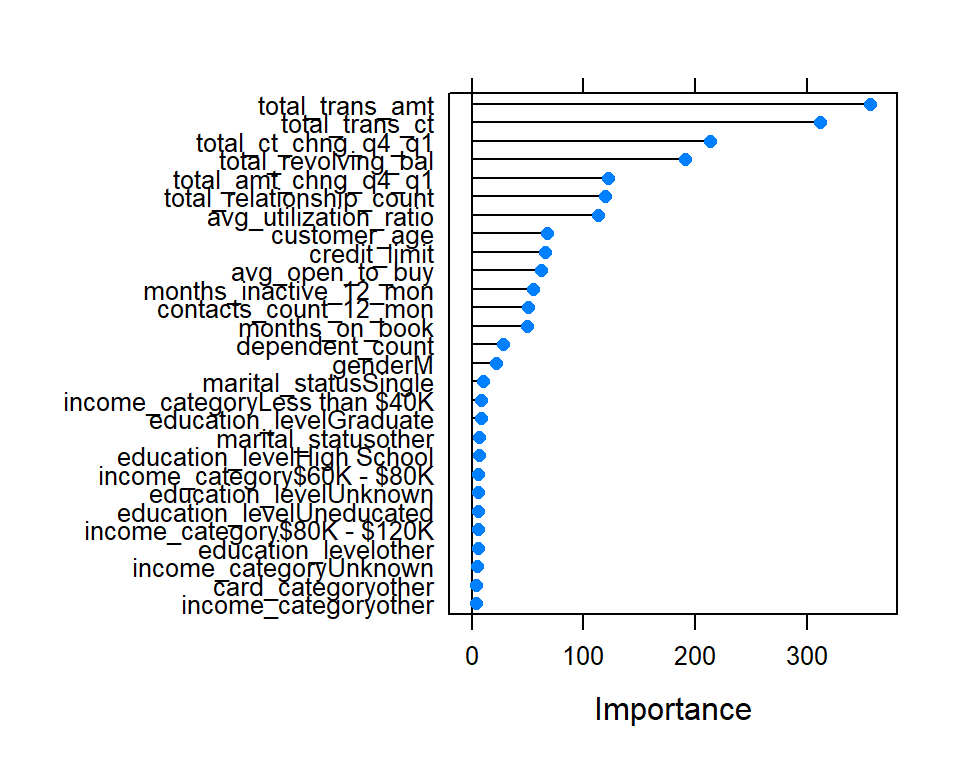

```r
plot(varImp(rf_gridsearch, scale = F))
```

```r
pred <- predict(rf_gridsearch, newdata = test, type = "raw")

cmatrix <- caret::confusionMatrix(pred, test$attrition_flag)
cmatrix
```

```
## Confusion Matrix and Statistics
##
##           Reference
## Prediction Attrited Existed
##   Attrited      392      30
##   Existed        97    2520
##
##                Accuracy : 0.9582
##                  95% CI : (0.9505, 0.965)
##     No Information Rate : 0.8391
##     P-Value [Acc > NIR] : < 2.2e-16
##
##                   Kappa : 0.8362
##
##  Mcnemar's Test P-Value : 4.726e-09
##
##             Sensitivity : 0.8016
##             Specificity : 0.9882
##          Pos Pred Value : 0.9289
##          Neg Pred Value : 0.9629
##              Prevalence : 0.1609
##          Detection Rate : 0.1290
##    Detection Prevalence : 0.1389
##       Balanced Accuracy : 0.8949
##
##        'Positive' Class : Attrited
##
```

```r
cmatrix$byClass
```

```
##          Sensitivity          Specificity       Pos Pred Value
##            0.8016360            0.9882353            0.9289100
##       Neg Pred Value            Precision               Recall
##            0.9629347            0.9289100            0.8016360
##                   F1           Prevalence       Detection Rate
##            0.8605928            0.1609082            0.1289898
## Detection Prevalence    Balanced Accuracy
##            0.1388615            0.8949356
```

**svm**

```r
splits <- initial_split(churn, prop = 0.7, strata = attrition_flag)

train <- training(splits)
test <- testing(splits)


set.seed(123)
control <- trainControl(method='cv',
                        number=5,
                        classProbs = T,
                        summaryFunction = twoClassSummary,
                        savePredictions = T
                        )

library(tictoc)
tic()
library(doParallel)
cl <- makePSOCKcluster(4)
registerDoParallel(cl)
svm_gridsearch <- train(attrition_flag ~ .,
                       data = train,
                       method = 'svmPoly',
                       trControl = control,
                       tuneLength = 3,
                       metric = "ROC",
                       verbose = F)
toc() # 343.98
```

```
## 105.46 sec elapsed
```

```r
stopCluster(cl)
svm_gridsearch
```

```
## Support Vector Machines with Polynomial Kernel
##
## 7088 samples
##   19 predictor
##    2 classes: 'Attrited', 'Existed'
##
## No pre-processing
## Resampling: Cross-Validated (5 fold)
## Summary of sample sizes: 5670, 5671, 5670, 5671, 5670
## Resampling results across tuning parameters:
##
##   degree  scale  C     ROC        Sens       Spec
##   1       0.001  0.25  0.8986866  0.6467463  0.9438655
##   1       0.001  0.50  0.8986653  0.6476273  0.9430252
##   1       0.001  1.00  0.8986807  0.6467463  0.9426891
```

[output cut: 27 more lines]

```r
train %>% str()
```

```
## tibble [7,088 x 20] (S3: tbl_df/tbl/data.frame)
##  $ customer_age            : int [1:7088] 66 54 48 47 53 48 48 46 53 68 ...
##  $ gender                  : Factor w/ 2 levels "F","M": 1 1 2 2 2 1 1 2 2 2 ...
##  $ dependent_count         : int [1:7088] 0 1 2 2 2 5 4 5 2 0 ...
##  $ education_level         : Factor w/ 6 levels "College","Graduate",..: 6 2 2 5 2 3 4 2 5 3 ...
##  $ marital_status          : Factor w/ 3 levels "Married","Single",..: 1 1 1 1 1 1 1 2 1 1 ...
##  $ income_category         : Factor w/ 6 levels "$40K - $60K",..: 5 4 2 3 3 4 4 3 3 4 ...
##  $ card_category           : Factor w/ 2 levels "Blue","other": 1 1 2 1 1 1 1 1 1 1 ...
##  $ months_on_book          : int [1:7088] 56 40 35 37 41 38 38 33 36 52 ...
##  $ total_relationship_count: int [1:7088] 5 2 2 2 3 1 3 6 2 1 ...
##  $ months_inactive_12_mon  : int [1:7088] 4 3 4 3 3 3 2 3 2 3 ...
##  $ contacts_count_12_mon   : int [1:7088] 3 1 4 3 2 3 3 3 1 2 ...
##  $ credit_limit            : num [1:7088] 7882 1438 34516 5449 11669 ...
##  $ total_revolving_bal     : int [1:7088] 605 808 0 1628 2227 0 0 2517 0 900 ...
##  $ avg_open_to_buy         : num [1:7088] 7277 630 34516 3821 9442 ...
##  $ total_amt_chng_q4_q1    : num [1:7088] 1.052 0.997 0.763 0.696 0.622 ...
##  $ total_trans_amt         : int [1:7088] 704 705 691 836 720 673 739 597 757 760 ...
##  $ total_trans_ct          : int [1:7088] 16 19 15 18 23 18 16 17 20 21 ...
##  $ total_ct_chng_q4_q1     : num [1:7088] 0.143 0.9 0.5 0.385 0.353 0.8 0.455 0.7 0.25 0.615 ...
##  $ avg_utilization_ratio   : num [1:7088] 0.077 0.562 0 0.299 0.191 0 0 0.076 0 0.626 ...
##  $ attrition_flag          : Factor w/ 2 levels "Attrited","Existed": 1 1 1 1 1 1 1 1 1 1 ...
##  - attr(*, ".internal.selfref")=<externalptr>
```

```r
# DALEX 2.0.1
library(DALEX)
ex <- DALEX::explain(model = svm_gridsearch,
               data = train[,-20],
               y = train$attrition_flag)
```

[output not shown]

```
##   -> residuals         :  numerical, min =  NA , mean =  NA , max =  NA
##   A new explainer has been created!
```

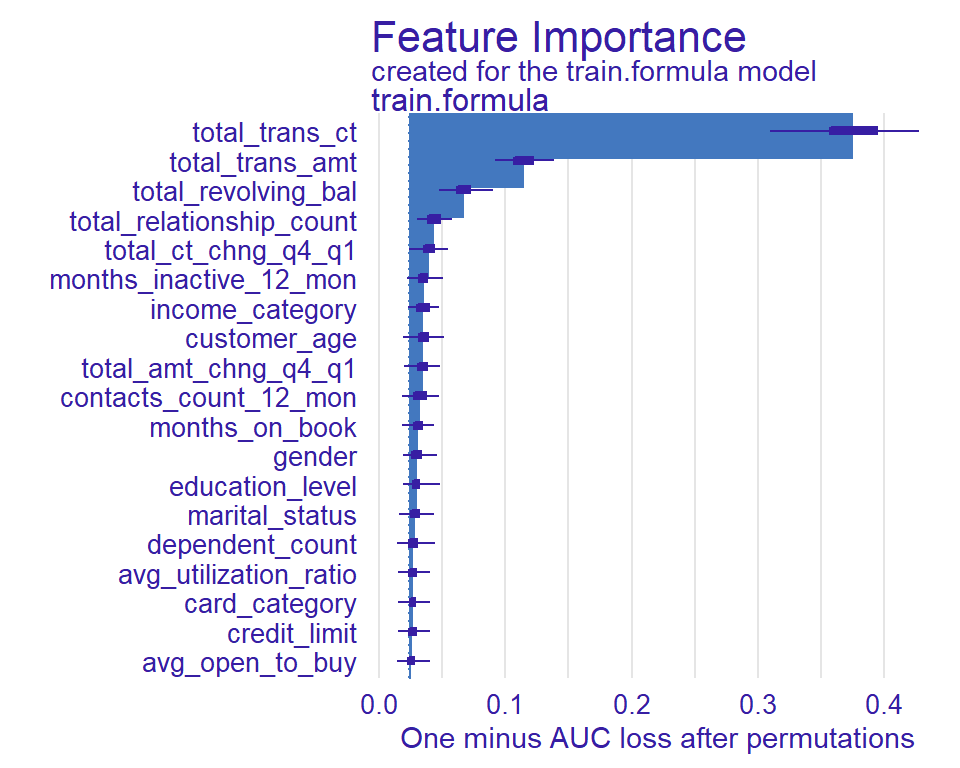

```r
vip <- model_parts(explainer = ex, B = 50)
plot(vip)
```

```r
pred <- predict(svm_gridsearch, newdata = test, type = "raw")

cmatrix <- caret::confusionMatrix(pred, test$attrition_flag)
cmatrix
```

```
## Confusion Matrix and Statistics
##
##           Reference
## Prediction Attrited Existed
##   Attrited      343      60
##   Existed       146    2490
##
##                Accuracy : 0.9322
##                  95% CI : (0.9227, 0.9409)
##     No Information Rate : 0.8391
##     P-Value [Acc > NIR] : < 2.2e-16
##
##                   Kappa : 0.7298
##
##  Mcnemar's Test P-Value : 3.176e-09
##
##             Sensitivity : 0.7014
##             Specificity : 0.9765
##          Pos Pred Value : 0.8511
##          Neg Pred Value : 0.9446
##              Prevalence : 0.1609
##          Detection Rate : 0.1129
##    Detection Prevalence : 0.1326
##       Balanced Accuracy : 0.8390
##
##        'Positive' Class : Attrited
##
```

```r
cmatrix$byClass
```

```
##          Sensitivity          Specificity       Pos Pred Value
##            0.7014315            0.9764706            0.8511166
##       Neg Pred Value            Precision               Recall
##            0.9446131            0.8511166            0.7014315
##                   F1           Prevalence       Detection Rate
##            0.7690583            0.1609082            0.1128661
## Detection Prevalence    Balanced Accuracy
##            0.1326094            0.8389510
```

**penalized logistic reg**

```r
library(doParallel)
cl <- makePSOCKcluster(4)
registerDoParallel(cl)
logit_gridsearch <- train(attrition_flag ~ .,
                       data = train,
                       method = 'glmnet',
                       trControl = control,
                       tuneLength = 20,
                       metric = "ROC")

logit_gridsearch
```

```
## glmnet
##
## 7088 samples
##   19 predictor
##    2 classes: 'Attrited', 'Existed'
##
## No pre-processing
## Resampling: Cross-Validated (5 fold)
## Summary of sample sizes: 5671, 5670, 5670, 5671, 5670
## Resampling results across tuning parameters:
##
##   alpha      lambda        ROC        Sens         Spec
##   0.1000000  6.536087e-05  0.9229738  0.586107891  0.9653782
##   0.1000000  1.013431e-04  0.9229738  0.586107891  0.9653782
##   0.1000000  1.571340e-04  0.9229738  0.586107891  0.9653782
##   0.1000000  2.436388e-04  0.9229338  0.584353505  0.9655462
##   0.1000000  3.777658e-04  0.9228422  0.583480176  0.9662185
##   0.1000000  5.857318e-04  0.9227026  0.580844733  0.9663866
##   0.1000000  9.081864e-04  0.9224536  0.577335961  0.9667227
##   0.1000000  1.408157e-03  0.9220806  0.572061210  0.9672269
##   0.1000000  2.183370e-03  0.9214388  0.563269959  0.9684034
##   0.1000000  3.385350e-03  0.9202208  0.554486436  0.9700840
##   0.1000000  5.249039e-03  0.9186085  0.536923255  0.9722689
##   0.1000000  8.138717e-03  0.9158779  0.507910194  0.9742857
##   0.1000000  1.261921e-02  0.9120902  0.478027668  0.9786555
##   0.1000000  1.956628e-02  0.9074243  0.453419893  0.9808403
##   0.1000000  3.033783e-02  0.9018734  0.423529639  0.9853782
##   0.1000000  4.703929e-02  0.8968327  0.365530567  0.9894118
##   0.1000000  7.293516e-02  0.8951133  0.273266868  0.9949580
##   0.1000000  1.130871e-01  0.8923642  0.168707010  0.9986555
##   0.1000000  1.753434e-01  0.8889163  0.035141819  0.9998319
##   0.1473684  6.536087e-05  0.9229893  0.586107891  0.9653782
##   0.1473684  1.013431e-04  0.9229893  0.586107891  0.9653782
##   0.1473684  1.571340e-04  0.9229893  0.586107891  0.9653782
##   0.1473684  2.436388e-04  0.9229434  0.584353505  0.9655462
##   0.1473684  3.777658e-04  0.9228481  0.582599119  0.9662185
##   0.1473684  5.857318e-04  0.9227218  0.579963676  0.9663866
##   0.1473684  9.081864e-04  0.9225246  0.577335961  0.9667227
##   0.1473684  1.408157e-03  0.9221509  0.572061210  0.9672269
##   0.1473684  2.183370e-03  0.9214847  0.563269959  0.9684034
```

[output cut: 340 more lines]

```
##   1.0000000  1.408157e-03  0.9228683  0.572934539  0.9665546
##   1.0000000  2.183370e-03  0.9224676  0.560626787  0.9682353
##   1.0000000  3.385350e-03  0.9216900  0.549200093  0.9690756
##   1.0000000  5.249039e-03  0.9200360  0.528108818  0.9710924
##   1.0000000  8.138717e-03  0.9161590  0.492943813  0.9739496
##   1.0000000  1.261921e-02  0.9071590  0.456016694  0.9798319
##   1.0000000  1.956628e-02  0.8960625  0.395401499  0.9838655
##   1.0000000  3.033783e-02  0.8936316  0.303133936  0.9910924
##   1.0000000  4.703929e-02  0.8828386  0.097534585  0.9986555
##   1.0000000  7.293516e-02  0.8603281  0.000000000  1.0000000
##   1.0000000  1.130871e-01  0.7944714  0.000000000  1.0000000
##   1.0000000  1.753434e-01  0.5000000  0.000000000  1.0000000
##
## ROC was used to select the optimal model using the largest value.
## The final values used for the model were alpha = 1 and lambda = 0.0003777658.
```

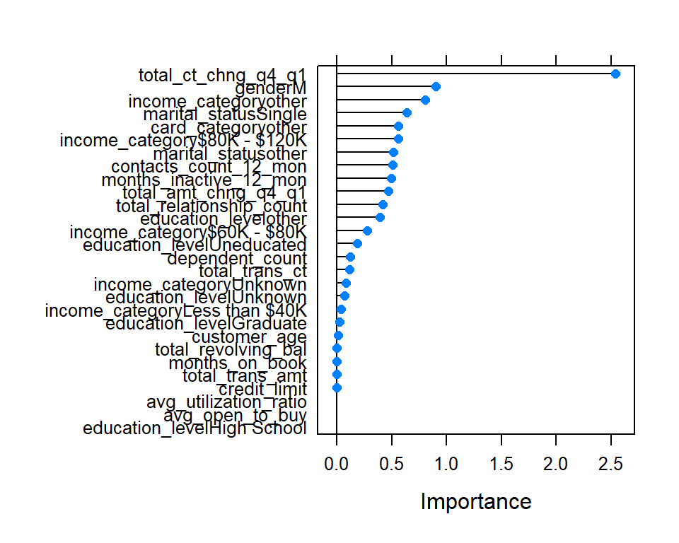

```r
stopCluster(cl)
plot(varImp(logit_gridsearch, scale = F))
```

```r
pred <- predict(logit_gridsearch, newdata = test, type = "raw")

cmatrix <- caret::confusionMatrix(pred, test$attrition_flag)
cmatrix
```

```
## Confusion Matrix and Statistics
##
##           Reference
## Prediction Attrited Existed
##   Attrited      278      76
##   Existed       211    2474
##
##                Accuracy : 0.9056
##                  95% CI : (0.8946, 0.9157)
##     No Information Rate : 0.8391
##     P-Value [Acc > NIR] : < 2.2e-16
##
##                   Kappa : 0.6064
##
##  Mcnemar's Test P-Value : 2.579e-15
##
##             Sensitivity : 0.56851
##             Specificity : 0.97020
##          Pos Pred Value : 0.78531
##          Neg Pred Value : 0.92142
##              Prevalence : 0.16091
##          Detection Rate : 0.09148
##    Detection Prevalence : 0.11649
##       Balanced Accuracy : 0.76935
##
##        'Positive' Class : Attrited
##
```

```r
cmatrix$byClass
```

```
##          Sensitivity          Specificity       Pos Pred Value
##           0.56850716           0.97019608           0.78531073
##       Neg Pred Value            Precision               Recall
##           0.92141527           0.78531073           0.56850716
##                   F1           Prevalence       Detection Rate
##           0.65954923           0.16090819           0.09147746
## Detection Prevalence    Balanced Accuracy
##           0.11648569           0.76935162
```

**logistic reg**

```r
library(doParallel)
cl <- makePSOCKcluster(4)
registerDoParallel(cl)
logit2_gridsearch <- train(attrition_flag ~ .,
                       data = train,
                       method = 'glm',
                       trControl = control,
                       tuneLength = 20,
                       metric = "ROC")
stopCluster(cl)
logit2_gridsearch
```

```
## Generalized Linear Model
##
## 7088 samples
##   19 predictor
##    2 classes: 'Attrited', 'Existed'
##
## No pre-processing
## Resampling: Cross-Validated (5 fold)
## Summary of sample sizes: 5671, 5670, 5671, 5670, 5670
## Resampling results:
##
##   ROC        Sens       Spec
##   0.9235992  0.5878584  0.9653782
```

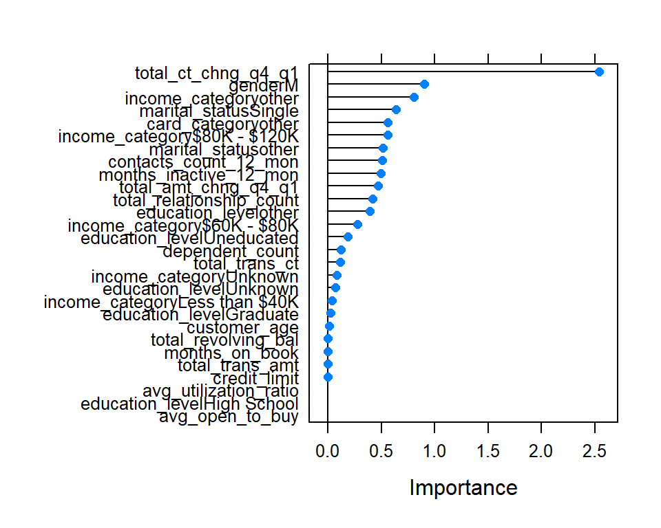

```r
plot(varImp(logit_gridsearch, scale = F))
```

```r
pred <- predict(logit2_gridsearch, newdata = test, type = "raw")
cmatrix <- caret::confusionMatrix(pred, test$attrition_flag)
cmatrix
```

```
## Confusion Matrix and Statistics
##
##           Reference
## Prediction Attrited Existed
##   Attrited      281      78
##   Existed       208    2472
##
##                Accuracy : 0.9059
##                  95% CI : (0.895, 0.916)
##     No Information Rate : 0.8391
##     P-Value [Acc > NIR] : < 2.2e-16
##
##                   Kappa : 0.6095
##
##  Mcnemar's Test P-Value : 2.386e-14
##
##             Sensitivity : 0.57464
##             Specificity : 0.96941
##          Pos Pred Value : 0.78273
##          Neg Pred Value : 0.92239
##              Prevalence : 0.16091
##          Detection Rate : 0.09246
##    Detection Prevalence : 0.11813
##       Balanced Accuracy : 0.77203
##
##        'Positive' Class : Attrited
##
```

```r
cmatrix$byClass
```

```
##          Sensitivity          Specificity       Pos Pred Value
##           0.57464213           0.96941176           0.78272981
##       Neg Pred Value            Precision               Recall
##           0.92238806           0.78272981           0.57464213
##                   F1           Prevalence       Detection Rate
##           0.66273585           0.16090819           0.09246463
## Detection Prevalence    Balanced Accuracy
##           0.11813096           0.77202695
```

## 1.4 3개 모델 앙상블 모형 생성 후 예측값 저장

**Averaging**

- classification일 때 예측값을 평균내는 것은 부적절
- 따라서 예측값 대신 예측 확률값을 평균 내서 최종 앙상블 결과로 산출

```r
result <- data.frame(rf = predict(rf_gridsearch, newdata = test, type = "prob"),
           svm = predict(svm_gridsearch, newdata = test, type = "prob"),
           logit = predict(logit2_gridsearch, newdata = test, type = "prob"))
result$average <- (result$rf.Existed + result$svm.Existed + result$logit.Existed)/3

result
```

```
##      rf.Attrited rf.Existed svm.Attrited  svm.Existed logit.Attrited
## 1          0.072      0.928 1.471188e-08 0.9999999853   4.748114e-03
## 2          0.028      0.972 2.971240e-06 0.9999970288   1.885313e-02
## 3          0.010      0.990 6.216095e-04 0.9993783905   2.636567e-02
## 4          0.012      0.988 2.402206e-09 0.9999999976   3.648888e-03
## 5          0.002      0.998 4.298638e-06 0.9999957014   3.080709e-03
## 6          0.010      0.990 1.854220e-04 0.9998145780   6.160485e-02
## 7          0.000      1.000 1.332756e-02 0.9866724449   2.369975e-02
## 8          0.822      0.178 9.920156e-01 0.0079843888   9.543526e-01
## 9          0.000      1.000 4.207379e-03 0.9957926211   2.512090e-02
## 10         0.064      0.936 2.169103e-04 0.9997830897   1.420263e-03
## 11         0.008      0.992 1.613294e-02 0.9838670566   6.718353e-02
## 12         0.050      0.950 9.722333e-02 0.9027766694   6.088737e-02
## 13         0.290      0.710 9.661978e-01 0.0338021880   9.004821e-01
## 14         0.000      1.000 8.839670e-03 0.9911603297   1.569346e-02
```

[output cut: 6065 more lines]

```r
result$average_c <- as.factor(ifelse(result$average>0.5, "E", "A"))

result %>% head()
```

```
##   rf.Attrited rf.Existed svm.Attrited svm.Existed logit.Attrited logit.Existed
## 1       0.072      0.928 1.471188e-08   1.0000000    0.004748114     0.9952519
## 2       0.028      0.972 2.971240e-06   0.9999970    0.018853133     0.9811469
## 3       0.010      0.990 6.216095e-04   0.9993784    0.026365668     0.9736343
## 4       0.012      0.988 2.402206e-09   1.0000000    0.003648888     0.9963511
## 5       0.002      0.998 4.298638e-06   0.9999957    0.003080709     0.9969193
## 6       0.010      0.990 1.854220e-04   0.9998146    0.061604852     0.9383951
##     average average_c
## 1 0.9744173         E
## 2 0.9843813         E
## 3 0.9876709         E
## 4 0.9947837         E
## 5 0.9983050         E
## 6 0.9760699         E
```

**Voting**

- 다수결 투표에 의해 최종 예측값을 산출하는 방식
- 모형이 3개 이므로 2개 이상 예측 결과가 같은 경우 최종 예측값으로 산출

```r
result2 <- data.frame(rf = predict(rf_gridsearch, newdata = test, type = "raw"),
           svm = predict(svm_gridsearch, newdata = test, type = "raw"),
           logit = predict(logit2_gridsearch, newdata = test, type = "raw"))
result2$voting <- as.factor(ifelse(result2$rf == "Existed" & result2$svm == "Existed", "E",
                                   ifelse(result2$rf == "Existed" & result2$logit == "Existed", "E",
                                          ifelse(result2$svm == "Existed" & result2$logit == "Existed", "E", "A"))))

result2 %>% head()
```

```
##        rf     svm   logit voting
## 1 Existed Existed Existed      E
## 2 Existed Existed Existed      E
## 3 Existed Existed Existed      E
## 4 Existed Existed Existed      E
## 5 Existed Existed Existed      E
## 6 Existed Existed Existed      E
```

**weighted average**

- 모델 별로 예측 정확도가 다르기 때문에 예측 정확도가 높은 모델에 더 큰 가중치를 부여한 후 평균을 내는 방식
- 예측 평가 지표는 임의로 선택하면 됨(모든 모델에 공통으로)

```r
# rf : 0.9868
# svm : 0.9306
# logit : 0.9042

rf_w <- 0.9868/(0.9868 + 0.9306 + 0.9042)
svm_w <- 0.9306/(0.9868 + 0.9306 + 0.9042)
logit_w <- 0.9042/(0.9868 + 0.9306 + 0.9042)



result3 <- data.frame(rf = predict(rf_gridsearch, newdata = test, type = "prob"),
           svm = predict(svm_gridsearch, newdata = test, type = "prob"),
           logit = predict(logit2_gridsearch, newdata = test, type = "prob"))
result3$average <- (result$rf.Existed*rf_w) + (result$svm.Existed*svm_w) + (result$logit.Existed*logit_w)

result3
```

```
##      rf.Attrited rf.Existed svm.Attrited  svm.Existed logit.Attrited
## 1          0.072      0.928 1.471188e-08 0.9999999853   4.748114e-03
## 2          0.028      0.972 2.971240e-06 0.9999970288   1.885313e-02
## 3          0.010      0.990 6.216095e-04 0.9993783905   2.636567e-02
## 4          0.012      0.988 2.402206e-09 0.9999999976   3.648888e-03
## 5          0.002      0.998 4.298638e-06 0.9999957014   3.080709e-03
## 6          0.010      0.990 1.854220e-04 0.9998145780   6.160485e-02
## 7          0.000      1.000 1.332756e-02 0.9866724449   2.369975e-02
## 8          0.822      0.178 9.920156e-01 0.0079843888   9.543526e-01
## 9          0.000      1.000 4.207379e-03 0.9957926211   2.512090e-02
## 10         0.064      0.936 2.169103e-04 0.9997830897   1.420263e-03
## 11         0.008      0.992 1.613294e-02 0.9838670566   6.718353e-02
## 12         0.050      0.950 9.722333e-02 0.9027766694   6.088737e-02
## 13         0.290      0.710 9.661978e-01 0.0338021880   9.004821e-01
## 14         0.000      1.000 8.839670e-03 0.9911603297   1.569346e-02
```

[output cut: 6065 more lines]

```r
result3$weight_average <- as.factor(ifelse(result3$average>0.5, "E", "A"))

result3 %>% head()
```

```
##   rf.Attrited rf.Existed svm.Attrited svm.Existed logit.Attrited logit.Existed
## 1       0.072      0.928 1.471188e-08   1.0000000    0.004748114     0.9952519
## 2       0.028      0.972 2.971240e-06   0.9999970    0.018853133     0.9811469
## 3       0.010      0.990 6.216095e-04   0.9993784    0.026365668     0.9736343
## 4       0.012      0.988 2.402206e-09   1.0000000    0.003648888     0.9963511
## 5       0.002      0.998 4.298638e-06   0.9999957    0.003080709     0.9969193
## 6       0.010      0.990 1.854220e-04   0.9998146    0.061604852     0.9383951
##     average weight_average
## 1 0.9732978              E
## 2 0.9841650              E
## 3 0.9878486              E
## 4 0.9946339              E
## 5 0.9983119              E
## 6 0.9766999              E
```

## 1.5 예측 결과 csv 제출

- raw or prob 구분해서 제출

# 2 시계열 데이터 분석

## 2.1 Data description

- 날짜 및 주가 수익률 데이터로 time series 변환 전 데이터 제공
- 주가 데이터는 계절 추세가 있는 데이터를 못찾아서 river flow에 대한 데이터로 대체함

## 2.2 데이터 로드, 정상성/이분산성 검증

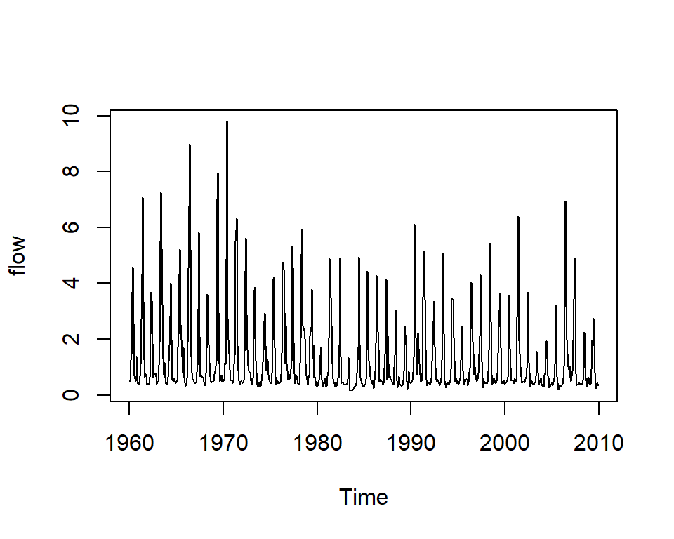

```r
flow <- ts(scan('https://online.stat.psu.edu/stat510/sites/stat510/files/data/coloradoflow.dat'),start = c("1960"), frequency = 12)
plot(flow)
```

```r
flow %>% length()
```

```
## [1] 600
```

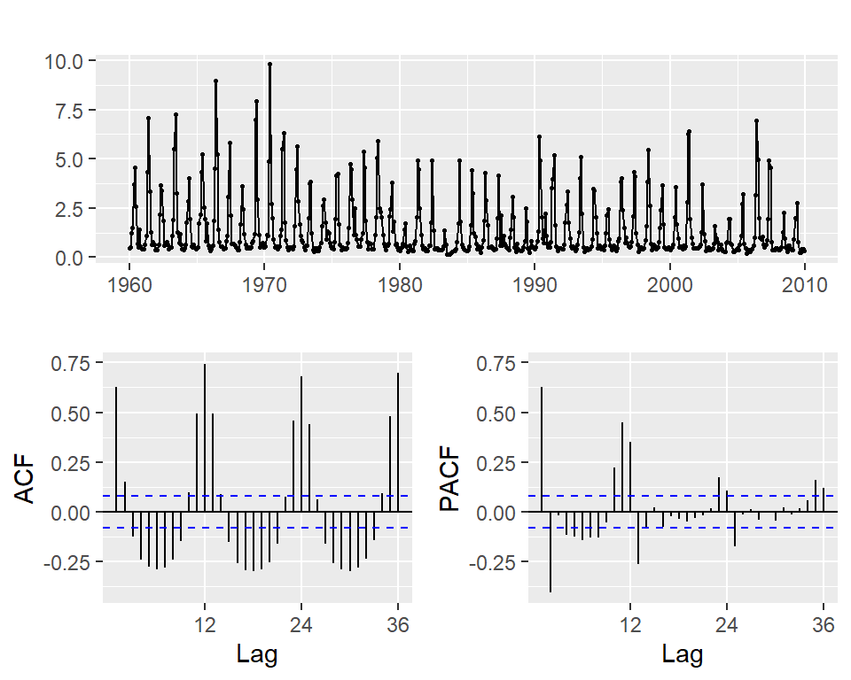

```r
ggtsdisplay(flow)
```

- 계절 추세가 존재하는 것으로 보임
- 일반 추세도 존재? 확인 필요

## 2.3 정상성 파악 근거에 따른 고정(stationary)시계열 여부 파악

- test 결과 일반 차분, 계절 차분 추천

```r
ndiffs(flow)
```

```
## [1] 1
```

```r
nsdiffs(flow)
```

```
## [1] 1
```

**계절 차분**

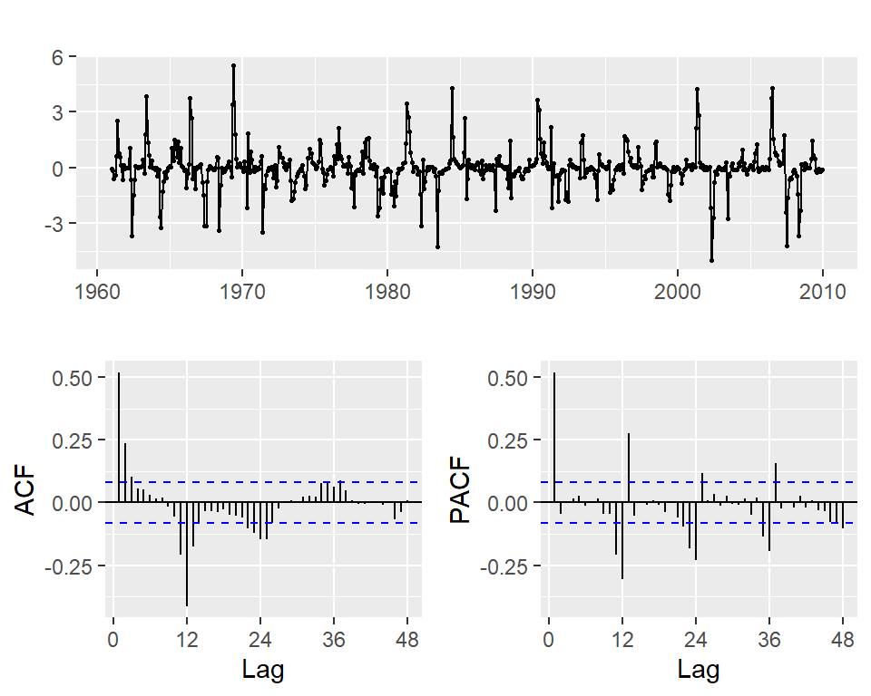

```r
flow_sdif <- diff(flow, 12)
ggtsdisplay(flow_sdif, lag.max = 48)
```

**일반 차분**

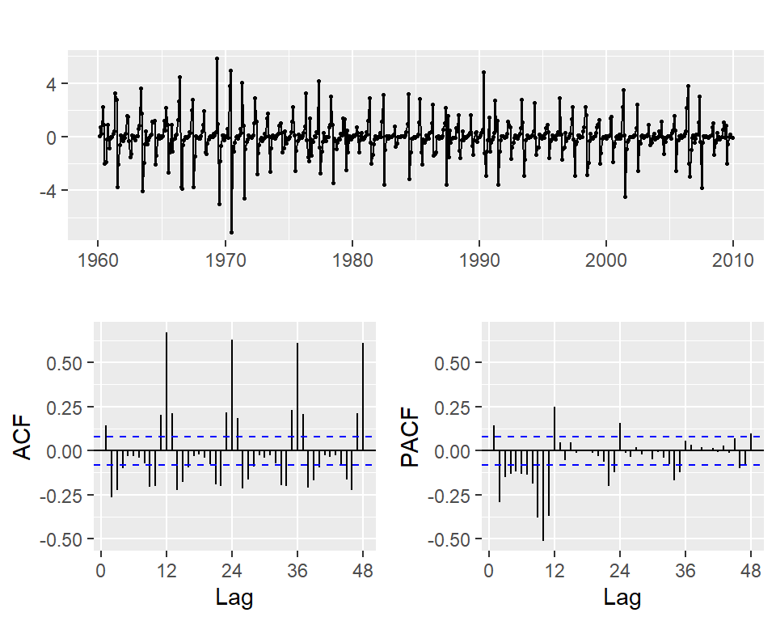

```r
flow_dif <- diff(flow, 1)
ggtsdisplay(flow_dif, lag.max = 48)
```

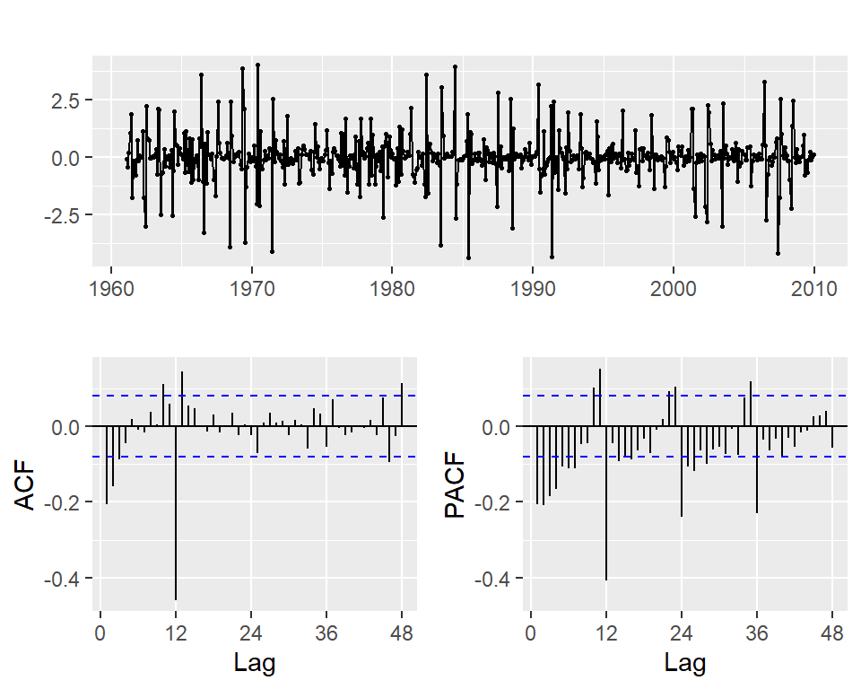

```r
flow_dif_s <- diff(flow_dif, lag = 12)
ggtsdisplay(flow_dif_s, lag.max = 48)
```

- 최종적으로 계절 차분만 해도 추세가 무작위 변동으로 바뀌었기 때문에 정상성 만족
- 굳이 일반 차분까지 할 필요 없을 듯?

## 2.4 SARIMA 분석 및 최적 모형 파라미터 선택

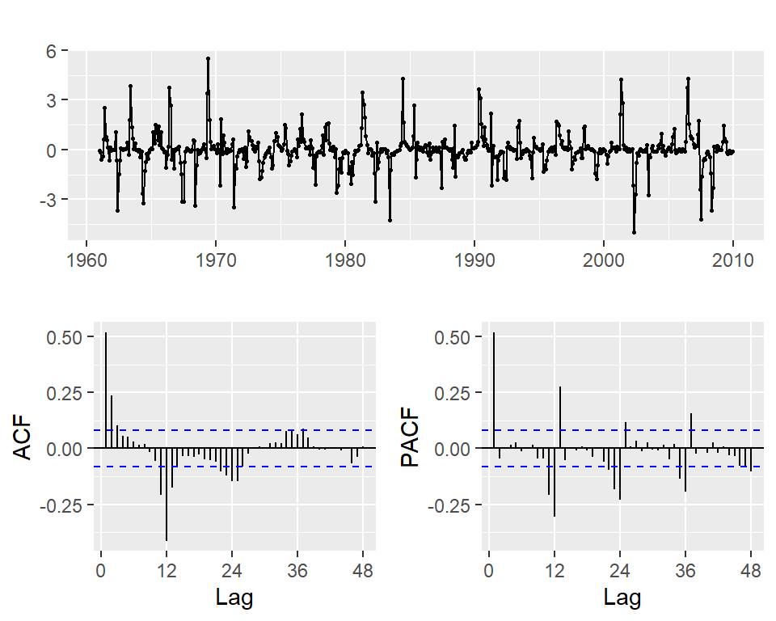

```r
flow_sdif <- diff(flow, 12)
ggtsdisplay(flow_sdif, lag.max = 48)
```

**후보모형** - ARIMA(1, 0, 0)(0, 1, 1)_12 - ARIMA(1, 0, 0)(0, 1, 2)_12

**ARIMA(1, 0, 0)(0, 1, 1)_12**

- 모든 모수 유의
- 모형 가정 만족 x

```r
fit1 <- Arima(flow_sdif, order=c(1,0,0), seasonal=list(order=c(0,1,1),period=12))
confint(fit1) # 모든 모수 유의
```

```
##           2.5 %     97.5 %
## ar1   0.4473195  0.5867711
## sma1 -1.0295533 -0.9704434
```

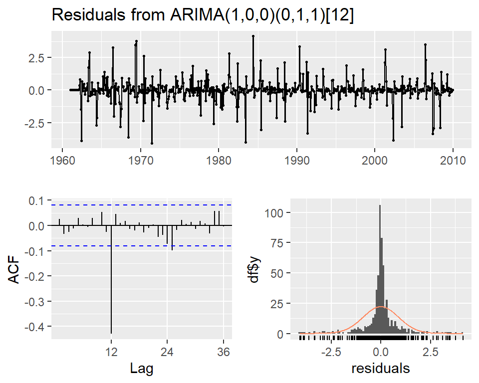

```
##
##  Ljung-Box test
##
## data:  Residuals from ARIMA(1,0,0)(0,1,1)[12]
## Q* = 122.85, df = 22, p-value = 5.551e-16
##
## Model df: 2.   Total lags used: 24
```

```r
checkresiduals(fit1) # 모형 가정 만족 x
```

**ARIMA(1, 0, 0)(0, 1, 2)_12**

- 모든 모수 유의
- 모형 가정 만족

```r
fit2 <- Arima(flow_sdif, order=c(1,0,0), seasonal=list(order=c(0,1,2),period=12))
confint(fit2) # 모든 모수 유의
```

```
##           2.5 %     97.5 %
## ar1   0.4425953  0.5825788
## sma1 -1.9978826 -1.7318198
## sma2  0.7466261  0.9835028
```

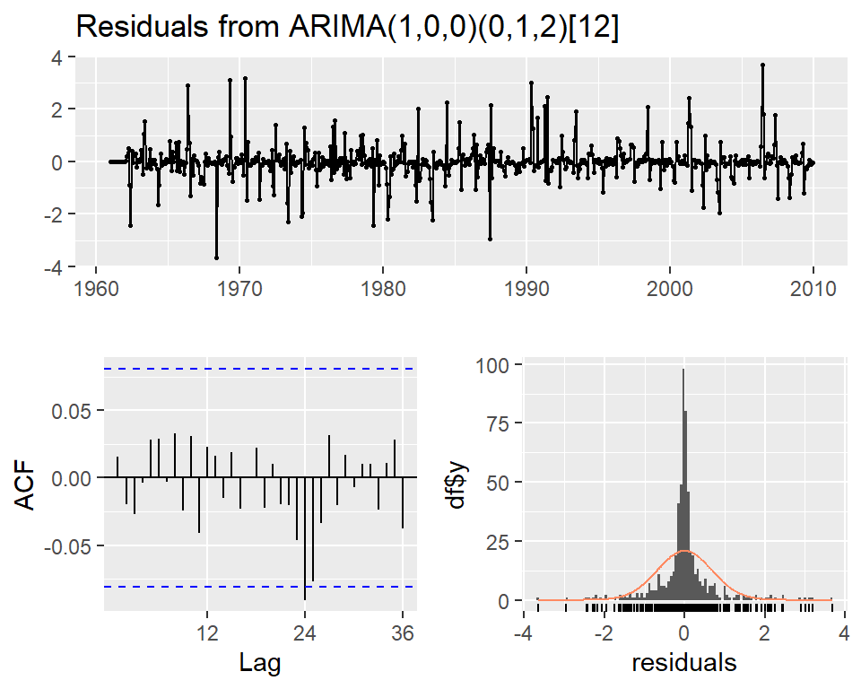

```
##
##  Ljung-Box test
##
## data:  Residuals from ARIMA(1,0,0)(0,1,2)[12]
## Q* = 13.051, df = 21, p-value = 0.9068
##
## Model df: 3.   Total lags used: 24
```

```r
checkresiduals(fit2) # 모형 가정 만족
```

- 추가된 모수 비유의
- 잠정 모형으로 선택

```r
confint(Arima(flow_sdif, order=c(2,0,0), seasonal=list(order=c(0,1,2),period=12)))
```

```
##           2.5 %      97.5 %
## ar1   0.4458651  0.60892216
## ar2  -0.1103860  0.05268102
## sma1 -1.9980407 -1.73258459
## sma2  0.7472272  0.98378061
```

```r
confint(Arima(flow_sdif, order=c(1,0,1), seasonal=list(order=c(0,1,2),period=12)))
```

```
##           2.5 %     97.5 %
## ar1   0.3335387  0.6104215
## ma1  -0.1011807  0.2115051
## sma1 -1.9985218 -1.7321168
## sma2  0.7469131  0.9841729
```

**auto.arima**

```r
fit3 <- auto.arima(flow, d = 0, D = 1)
confint(fit3)
```

```
##           2.5 %    97.5 %
## ar1   0.4505523 0.5888774
## sar1 -0.8926029 0.4232096
## sma1 -1.2435069 0.0515665
## sma2 -0.8189905 0.3069674
```

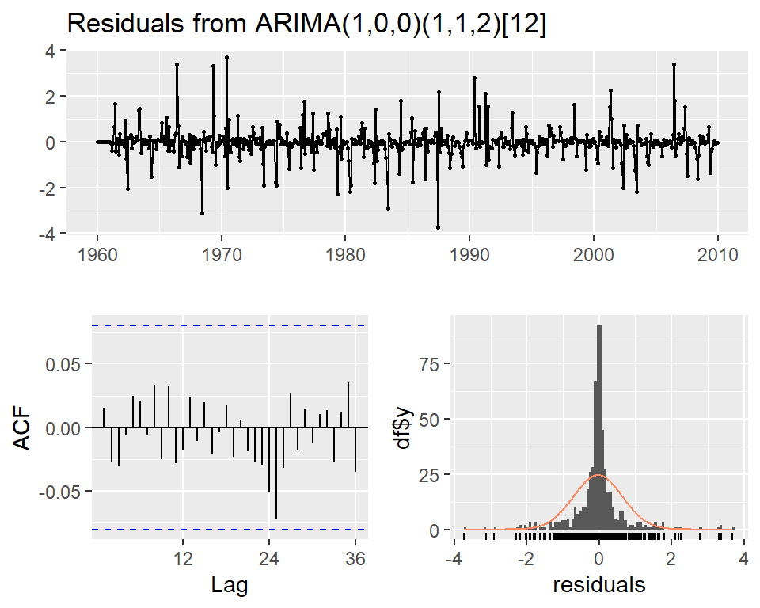

```
##
##  Ljung-Box test
##
## data:  Residuals from ARIMA(1,0,0)(1,1,2)[12]
## Q* = 8.5294, df = 20, p-value = 0.9877
##
## Model df: 4.   Total lags used: 24
```

```r
checkresiduals(fit3)
```

- 추가된 모수 비유의
- ARIMA(1, 0, 0)(1, 1, 2)_12 잠정 모형으로 선택

```r
confint(Arima(flow_sdif, order=c(2,0,0), seasonal=list(order=c(1,1,2),period=12)))
```

```
##            2.5 %      97.5 %
## ar1   0.44669939  0.60977847
## ar2  -0.11265366  0.05059945
## sar1 -0.04492129  0.14621142
## sma1 -2.04435285 -1.71719917
## sma2  0.73566483  1.02700654
```

```r
confint(Arima(flow_sdif, order=c(1,0,1), seasonal=list(order=c(1,1,2),period=12)))
```

```
##            2.5 %     97.5 %
## ar1   0.33052661  0.6083778
## ma1  -0.09794919  0.2154516
## sar1 -0.04441389  0.1462830
## sma1 -2.06871030 -1.7012281
## sma2  0.72034018  1.0498119
```

- aic, bic 비교 결과 ARIMA(1, 0, 0)(0, 1, 2)_12를 최종 모형으로 선택

```r
fit2 <- Arima(flow_sdif, order=c(1,0,0), seasonal=list(order=c(0,1,2),period=12))
fit3 <- Arima(flow_sdif, order=c(1,0,0), seasonal=list(order=c(1,1,2),period=12))

c(fit2$aic, fit3$aic)
```

```
## [1] 1320.247 1321.225
```

```r
c(fit2$bic, fit3$bic)
```

```
## [1] 1337.672 1343.006
```

## 2.5 잔차 그래프 출력

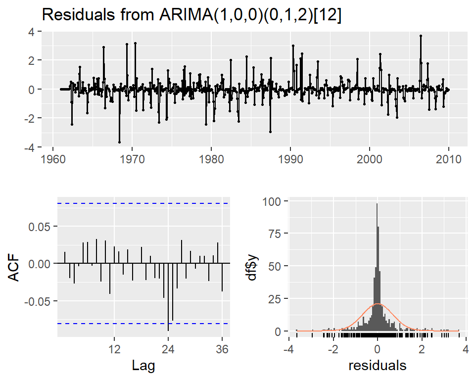

```
##
##  Ljung-Box test
##
## data:  Residuals from ARIMA(1,0,0)(0,1,2)[12]
## Q* = 13.051, df = 21, p-value = 0.9068
##
## Model df: 3.   Total lags used: 24
```

```r
checkresiduals(fit2)
```

## 2.6 분석 결과 PDF 제출

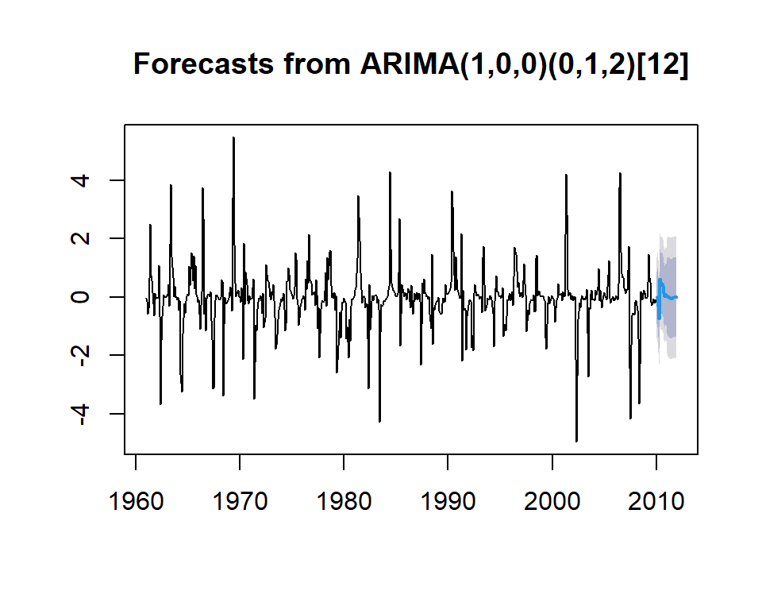

```r
plot(forecast(fit2))
```